# Project 2, Dataset 2

Alice Ding

2023-02-27

## Overview

For this dataset, I’ll be using the first one posted by Waheeb and it represents sales data for different product lines based on a specific date. This data has one row per date and includes the following columns:

- Date
- Product Line 1
- Product Line 2
- Product Line 3

The last three columns are dollar values.

```r
product_data <- read.csv("https://raw.githubusercontent.com/addsding/data607/main/project2/product-lines.csv")
head(product_data)
```

|  | Date | Product.Line.1 | Product.Line.2 | Product.Line.3 |
| --- | --- | --- | --- | --- |
| 1 | 1/17/23 | 2500 | 1250 | 5000 |
| 2 | 2/4/23 | 1000 | 1000 | 4500 |
| 3 | 4/8/23 | 980 | 2000 | 850 |
| 4 | 5/7/23 | 990 | 3000 | 976 |
| 5 | 6/17/23 | 3000 | 5000 | 1500 |

Our goal is to flatten this table to be one row per date and product line number combination before beginning analysis.

## Tidying the Data

To clean this data frame, we’ll be pivoting it.

```r
product_data_pivot <- pivot_longer(
  product_data, cols=2:4, names_to="product_line", values_to="sales"
  )
head(product_data_pivot)
```

| Date | product_line | sales |
| --- | --- | --- |
| 1/17/23 | Product.Line.1 | 2500 |
| 1/17/23 | Product.Line.2 | 1250 |
| 1/17/23 | Product.Line.3 | 5000 |
| 2/4/23 | Product.Line.1 | 1000 |
| 2/4/23 | Product.Line.2 | 1000 |
| 2/4/23 | Product.Line.3 | 4500 |

The pivot has worked! There are however periods instead of spaces in the `product_line` column so we’ll replace those. Also, the `Date` column also should be changed into an actual date.

```r
product_data_pivot$product_line <- gsub("\\.", " ", product_data_pivot$product_line)

product_data_pivot$Date <- as.Date(product_data_pivot$Date,
  format = "%m/%d/%y")

head(product_data_pivot)
```

| Date | product_line | sales |
| --- | --- | --- |
| 2023-01-17 | Product Line 1 | 2500 |
| 2023-01-17 | Product Line 2 | 1250 |
| 2023-01-17 | Product Line 3 | 5000 |
| 2023-02-04 | Product Line 1 | 1000 |
| 2023-02-04 | Product Line 2 | 1000 |
| 2023-02-04 | Product Line 3 | 4500 |

Looks good, time to analyze!

## Analysis

To begin, we can find the stats for sales for each product line.

```r
sales <- product_data_pivot |>
  group_by(product_line) |>
  summarise(mean_sales = mean(sales),
            median_sales = median(sales),
            min_sales = min(sales),
            max_sales = max(sales),
            .groups = 'drop')

sales
```

| product_line | mean_sales | median_sales | min_sales | max_sales |
| --- | --- | --- | --- | --- |
| Product Line 1 | 1694.0 | 1000 | 980 | 3000 |
| Product Line 2 | 2450.0 | 2000 | 1000 | 5000 |
| Product Line 3 | 2565.2 | 1500 | 850 | 5000 |

On average, product line 3 seems to be doing the best as on average, it has sales of $2,500+. Product line 2 isn’t that far behind at $2,450, while product line 1 seems to trail behind at only $1,700. We can see though that product line 3 has a pretty large range of sales from $850 to $5,000 – could this be due to seasonality?

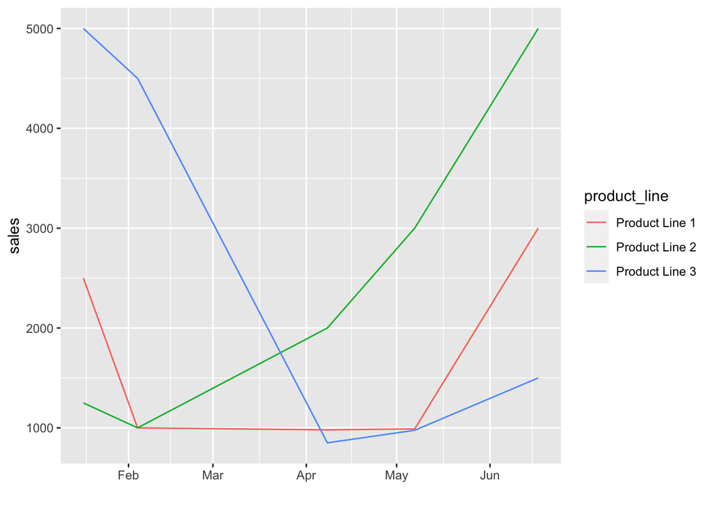

```r
product_time_series <- ggplot(product_data_pivot, aes(x=Date, y=sales, color=product_line)) +
  geom_line() +
  xlab("")
product_time_series
```

When looking at this data over time, it tells a very different story. Product line 2 seems to be growing a lot while product line 3 has not been doing so well, really tanking in sales for the first quarter of the year. Product line 1 was relatively consistent after a pretty huge drop from January to February, however seems to be bouncing back as of June.

## Conclusion

Overall, this data was relatively simple to clean and the findings were pretty straight-forward. Two piece of informations that I think are super important here though is supply as well as overall price of each product line – we can’t really compare the performance of each product line without knowing how much each unit costs as well as how much was actually produced. If for example, product line 1 is priced at a lower tier and had less units made, its performance would actually be more impressive if product line 3 was over-produced and was at a much higher price point. To continue with this analysis, we’d definitely need these data points at the very least to fully gage how well each product line is performing.